# BIOS 545 - 2019 - Lecture 6: tidyr and readr package

Ziyi Li (ziyi.li@emory.edu)

## 1. Tidyr package:

The package `tidyr`

- written by Hadley Wickham.
- addresses the common problem of wanting to **reshape your data** for plotting and use by different R functions.
- Sometimes we want data sets where we have one row per measurement. Sometimes we want a data frame where each measurement type has its own column, and rows are instead more aggregated groups. **Moving back and forth between these formats is nontrivial**.
- `tidyr` gives you tools for this and more sophisticated data manipulation.

- `separate()`
- `unite()`
- `gather()`
- `spread()`

### 1.1 Install and load package

```r
# install.packages("tidyr")

library("tidyr")
```

### 1.2 `separate()` can split a function into two (or more) columns.

```r
musicians <- data.frame(FirstName = c("Frederic", "Wolfgang", "Ludwig"),
                        LastName = c("Chopin", "Mozart", "Beethoven"),
                        YearBorn = c(1810, 1756, 1770),
                        YearDeath = c(1849, 1791, 1827),
                        BornPlace = c("Zelezowa, Poland", "Salzburg, Austria", "Mechelen, German"))
musicians
```

```
##   FirstName  LastName YearBorn YearDeath         BornPlace
## 1  Frederic    Chopin     1810      1849  Zelezowa, Poland
## 2  Wolfgang    Mozart     1756      1791 Salzburg, Austria
## 3    Ludwig Beethoven     1770      1827  Mechelen, German
```

```r
# separete(dataset_name, variables_to_separate, names_of_new_columns, separator)
separate(musicians, BornPlace, c("City", "Country"), sep=",")
```

```
##   FirstName  LastName YearBorn YearDeath     City  Country
## 1  Frederic    Chopin     1810      1849 Zelezowa   Poland
## 2  Wolfgang    Mozart     1756      1791 Salzburg  Austria
## 3    Ludwig Beethoven     1770      1827 Mechelen   German
```

```r
#unite(dataset_name, new_column_name, columns_to_unite, separator)
unite(musicians, "FullName", c(FirstName, LastName), sep=" ")
```

```
##           FullName YearBorn YearDeath         BornPlace
## 1  Frederic Chopin     1810      1849  Zelezowa, Poland
## 2  Wolfgang Mozart     1756      1791 Salzburg, Austria
## 3 Ludwig Beethoven     1770      1827  Mechelen, German
```

### 1.4 `gather()` can transform data from wide-format to long-format.

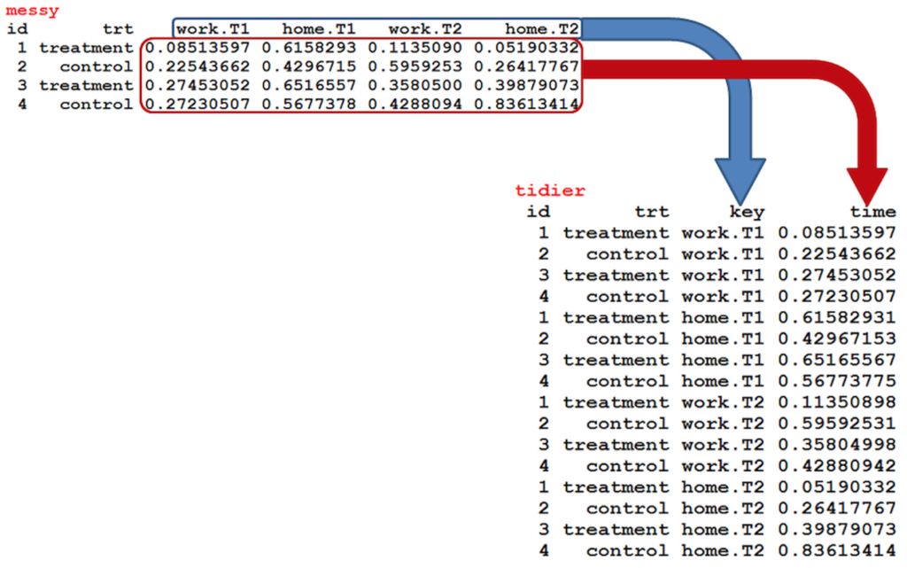

[Ref](https://uc-r.github.io/tidyr).

```r
worknum <- data.frame(Name = c("Chopin", "Mozart", "Beethoven"),
                        Etude = c(103, 80, 46),
                        Waltz = c(36, 12, 54),
                        Symphony = c(24, 41, 55))

worknum
```

```
##        Name Etude Waltz Symphony
## 1    Chopin   103    36       24
## 2    Mozart    80    12       41
## 3 Beethoven    46    54       55
```

```r
# gather(dataset_name, new_variable_name1, new_variable_name2, variables_to_stack)
worknum2 <- gather(worknum, work_type, num_work, Etude:Symphony)
worknum2
```

```
##        Name work_type num_work
## 1    Chopin     Etude      103
## 2    Mozart     Etude       80
## 3 Beethoven     Etude       46
## 4    Chopin     Waltz       36
## 5    Mozart     Waltz       12
## 6 Beethoven     Waltz       54
## 7    Chopin  Symphony       24
## 8    Mozart  Symphony       41
## 9 Beethoven  Symphony       55
```

### 1.5 `spread()` can transform data from long-format to wide-format.

```r
#spread(dataset_name, column_to_be_spread, values_that_multiple_columns_take)
spread(worknum2, work_type, num_work)
```

```
##        Name Etude Symphony Waltz
## 1 Beethoven    46       55    54
## 2    Chopin   103       24    36
## 3    Mozart    80       41    12
```

## 2. Readr package:

The package `readr`

- written by Hadley Wickham.
- the commonly used `read.table()` and `read.csv()` functions are provided by the basic function **Utils**.
- Compared to the **Utils** package, **readr** is multiple times faster, very easy to use and have consistent names.

<reference: https://www.youtube.com/watch?v=opai4Wmp6Zo&t=172s.>

### 2.1 Install and load readr package.

```r
# install.packages("readr")
library(readr)
```

### 2.2 Quick start: read_delim()

The core function in **readr** is `read_delim()`, which have similar functions to `read.csv()`. Example: read in a NBA player data csv file,

```r
file_location <- "https://www.dropbox.com/s/ialbx8rgvqnofif/player_data.csv?dl=1"
out1 <- read_delim(file_location, delim=",")
head(out1)
```

```
## # A tibble: 6 x 8
##   name    year_start year_end position height weight birth_date college
##   <chr>        <dbl>    <dbl> <chr>    <chr>   <dbl> <chr>      <chr>
## 1 Alaa A…       1991     1995 F-C      10-Jun    240 24-Jun-68  Duke Unive…
## 2 Zaid A…       1969     1978 C-F      9-Jun     235 7-Apr-46   Iowa State…
## 3 Kareem…       1970     1989 C        2-Jul     225 16-Apr-47  University…
## 4 Mahmou…       1991     2001 G        1-Jun     162 9-Mar-69   Louisiana …
## 5 Tariq …       1998     2003 F        6-Jun     223 3-Nov-74   San Jose S…
## 6 Sharee…       1997     2008 F        9-Jun     225 11-Dec-76  University…
```

```r
out2 <- read.csv(file_location, sep=",", header = TRUE)
head(out2)
```

```
##                  name year_start year_end position height weight
## 1      Alaa Abdelnaby       1991     1995      F-C 10-Jun    240
## 2     Zaid Abdul-Aziz       1969     1978      C-F  9-Jun    235
## 3 Kareem Abdul-Jabbar       1970     1989        C  2-Jul    225
## 4  Mahmoud Abdul-Rauf       1991     2001        G  1-Jun    162
## 5   Tariq Abdul-Wahad       1998     2003        F  6-Jun    223
## 6 Shareef Abdur-Rahim       1997     2008        F  9-Jun    225
##   birth_date                               college
## 1  24-Jun-68                       Duke University
## 2   7-Apr-46                 Iowa State University
## 3  16-Apr-47 University of California, Los Angeles
## 4   9-Mar-69            Louisiana State University
## 5   3-Nov-74             San Jose State University
## 6  11-Dec-76              University of California
```

Assign column names by `col_names`,

```r
file_location <- "https://www.dropbox.com/s/zplirj7l3uix9tb/player_data2.csv?dl=1"
out3 <- read_delim(file_location, delim = ",", col_names = FALSE)
head(out3)
```

```
## # A tibble: 6 x 8
##   X1               X2    X3 X4    X5       X6 X7      X8
##   <chr>         <dbl> <dbl> <chr> <chr> <dbl> <chr>   <chr>
## 1 Alaa Abdelna…  1991  1995 F-C   10-J…   240 24-Jun… Duke University
## 2 Zaid Abdul-A…  1969  1978 C-F   9-Jun   235 7-Apr-… Iowa State University
## 3 Kareem Abdul…  1970  1989 C     2-Jul   225 16-Apr… University of Califo…
## 4 Mahmoud Abdu…  1991  2001 G     1-Jun   162 9-Mar-… Louisiana State Univ…
## 5 Tariq Abdul-…  1998  2003 F     6-Jun   223 3-Nov-… San Jose State Unive…
## 6 Shareef Abdu…  1997  2008 F     9-Jun   225 11-Dec… University of Califo…
```

```r
out4 <- read_delim(file_location, delim = ",",
                   col_names = c("name","year_start","year_end","position",
                                 "height", "weight", "birth_date","college"))
head(out4)
```

```
## # A tibble: 6 x 8
##   name    year_start year_end position height weight birth_date college
##   <chr>        <dbl>    <dbl> <chr>    <chr>   <dbl> <chr>      <chr>
## 1 Alaa A…       1991     1995 F-C      10-Jun    240 24-Jun-68  Duke Unive…
## 2 Zaid A…       1969     1978 C-F      9-Jun     235 7-Apr-46   Iowa State…
## 3 Kareem…       1970     1989 C        2-Jul     225 16-Apr-47  University…
## 4 Mahmou…       1991     2001 G        1-Jun     162 9-Mar-69   Louisiana …
## 5 Tariq …       1998     2003 F        6-Jun     223 3-Nov-74   San Jose S…
## 6 Sharee…       1997     2008 F        9-Jun     225 11-Dec-76  University…
```

Specify column type by `col_types`. If not specify column types, read_delim will guess the type of each column by the first 30 observations.

```r
sapply(out4, class)
```

```
##        name  year_start    year_end    position      height      weight
## "character"   "numeric"   "numeric" "character" "character"   "numeric"
##  birth_date     college
## "character" "character"
```

```r
file_location <- "https://www.dropbox.com/s/ialbx8rgvqnofif/player_data.csv?dl=1"
out5 <- read_delim(file_location, delim=",", col_types = "ccdccdcc")
head(out5)
```

```
## # A tibble: 6 x 8
##   name    year_start year_end position height weight birth_date college
##   <chr>   <chr>         <dbl> <chr>    <chr>   <dbl> <chr>      <chr>
## 1 Alaa A… 1991           1995 F-C      10-Jun    240 24-Jun-68  Duke Unive…
## 2 Zaid A… 1969           1978 C-F      9-Jun     235 7-Apr-46   Iowa State…
## 3 Kareem… 1970           1989 C        2-Jul     225 16-Apr-47  University…
## 4 Mahmou… 1991           2001 G        1-Jun     162 9-Mar-69   Louisiana …
## 5 Tariq … 1998           2003 F        6-Jun     223 3-Nov-74   San Jose S…
## 6 Sharee… 1997           2008 F        9-Jun     225 11-Dec-76  University…
```

| Notation | Meaning |
| --- | --- |
| c | character |
| d | double |
| i | integer |
| l | logical |
| _ | skip |

We can use “_" to skip column(s):

```r
file_location <- "/Users/Ziyi/Dropbox/BIOS545_2019/supp/player_data.csv"
out6 <- read_delim(file_location, delim=",", col_types = "cddc____")
head(out6)
```

```
## # A tibble: 6 x 4
##   name                year_start year_end position
##   <chr>                    <dbl>    <dbl> <chr>
## 1 Alaa Abdelnaby            1991     1995 F-C
## 2 Zaid Abdul-Aziz           1969     1978 C-F
## 3 Kareem Abdul-Jabbar       1970     1989 C
## 4 Mahmoud Abdul-Rauf        1991     2001 G
## 5 Tariq Abdul-Wahad         1998     2003 F
## 6 Shareef Abdur-Rahim       1997     2008 F
```

Select observations to read in by `skip` and `n_max`:

```r
head(out1)
```

```
## # A tibble: 6 x 8
##   name    year_start year_end position height weight birth_date college
##   <chr>        <dbl>    <dbl> <chr>    <chr>   <dbl> <chr>      <chr>
## 1 Alaa A…       1991     1995 F-C      10-Jun    240 24-Jun-68  Duke Unive…
## 2 Zaid A…       1969     1978 C-F      9-Jun     235 7-Apr-46   Iowa State…
## 3 Kareem…       1970     1989 C        2-Jul     225 16-Apr-47  University…
## 4 Mahmou…       1991     2001 G        1-Jun     162 9-Mar-69   Louisiana …
## 5 Tariq …       1998     2003 F        6-Jun     223 3-Nov-74   San Jose S…
## 6 Sharee…       1997     2008 F        9-Jun     225 11-Dec-76  University…
```

```r
## skip the first two rows, read in up to 3 rows
out7 <- read_delim(file_location, delim=",", skip = 2, n_max = 3)
head(out7)
```

```
## # A tibble: 3 x 8
##   `Zaid Abdul-Azi… `1969` `1978` `C-F` `9-Jun` `235` `7-Apr-46`
##   <chr>             <dbl>  <dbl> <chr> <chr>   <dbl> <chr>
## 1 Kareem Abdul-Ja…   1970   1989 C     2-Jul     225 16-Apr-47
## 2 Mahmoud Abdul-R…   1991   2001 G     1-Jun     162 9-Mar-69
## 3 Tariq Abdul-Wah…   1998   2003 F     6-Jun     223 3-Nov-74
## # … with 1 more variable: `Iowa State University` <chr>
```

```r
## manually type in column names
out8 <- read_delim(file_location, delim = ",", skip = 2, n_max = 3,
                   col_names = c("name","year_start","year_end","position",
                                 "height", "weight", "birth_date","college"))
head(out8)
```

```
## # A tibble: 3 x 8
##   name    year_start year_end position height weight birth_date college
##   <chr>        <dbl>    <dbl> <chr>    <chr>   <dbl> <chr>      <chr>
## 1 Zaid A…       1969     1978 C-F      9-Jun     235 7-Apr-46   Iowa State…
## 2 Kareem…       1970     1989 C        2-Jul     225 16-Apr-47  University…
## 3 Mahmou…       1991     2001 G        1-Jun     162 9-Mar-69   Louisiana …
```

| utils | readr |
| --- | --- |
| read.table() | read_delim() |
| read.csv() | read_csv() |
| read.tsv() | read_tsv() |